# Using quantified Voice Patterns to diagnose the severity of Parkinson’s disease

David Northey

2024-04-22

### **Abstract**

Diagnosis for Parkinson’s Disease is a time-consuming endeavor requiring trained medical staff which can take years to perform accurate assessment. The purpose of this report is to use quantified voice patterns to determine the severity of Parkinson’s disease. If successful, this would be a less invasive diagnostic tool than conventional methods. To do this we used Principal Component Analysis (PCA) to reduce the dimensionality of the dataset. The output from this unsupervised learning technique provides low multicollinearity data which meets the assumptions required to perform some of the supervised learning algorithms. These include logistic regression, random forest and K-Nearest Neighbours (kNN). Following these methods, a further unsupervised learning of cluster analysis using k-means was untilised to further explore the nature of the dataset.

The supervised learning models produced based on quantified voice pattern analysis in this investigation performed poorly unfortunately. The random forest and K-NN performed the best but given the small number of patients, the accuracy misdiagnosed patients too readily. Using this dataset, we were unable to accurately predict the severity of Parkinson’s disease. When visualising the data Using cluster analysis by k means, most of the data forms in one cluster. Further data collection and analysis will be required to develop better prediction models for Parkinson’s disease.

### **Introduction**

Parkinson’s Disease is a serious medical condition that affects the nervous system. Some diagnostic tools used to determine the severity of the condition include both motor and total Unified Parkinson’s Disease Rating Scale (UPDRS). Diagnosing Parkinson’s disease can take years too accurately diagnose (Tsanas. A, et al, 2009) requiring a lot of resource, being able to develop new, quicker methods to aid in this diagnosis would be advantageous.

The objectives of this report is to create an accurate training model that can effectively predict whether or not a patient is in two categories of Parkinson’s disease, these two categories are ‘mild’ and ‘advanced’. If this can be performed effectively, then voice pattern analysis could be used to accompany or even replace conventional diagnostic techniques for Parkinson’s disease.

```r
library(tidyverse)
library(mice)
library(MASS)
library(factoextra)
library(caret)
library(plotly)
library(GGally)
library(pROC)
```

```r
parkinsons_data <- read.csv("parkinsons_updrs.data") #Load the parkinsons dataset
```

```r
str(parkinsons_data) # View classes of the dataset
```

```
## 'data.frame':    5875 obs. of  22 variables:
##  $ subject.     : int  1 1 1 1 1 1 1 1 1 1 ...
##  $ age          : int  72 72 72 72 72 72 72 72 72 72 ...
##  $ sex          : int  0 0 0 0 0 0 0 0 0 0 ...
##  $ test_time    : num  5.64 12.67 19.68 25.65 33.64 ...
##  $ motor_UPDRS  : num  28.2 28.4 28.7 28.9 29.2 ...
##  $ total_UPDRS  : num  34.4 34.9 35.4 35.8 36.4 ...
##  $ Jitter...    : num  0.00662 0.003 0.00481 0.00528 0.00335 0.00353 0.00422 0.00476 0.00432 0.00496 ...
##  $ Jitter.Abs.  : num  3.38e-05 1.68e-05 2.46e-05 2.66e-05 2.01e-05 ...
##  $ Jitter.RAP   : num  0.00401 0.00132 0.00205 0.00191 0.00093 0.00119 0.00212 0.00226 0.00156 0.00258 ...
##  $ Jitter.PPQ5  : num  0.00317 0.0015 0.00208 0.00264 0.0013 0.00159 0.00221 0.00259 0.00207 0.00253 ...
##  $ Jitter.DDP   : num  0.01204 0.00395 0.00616 0.00573 0.00278 ...
##  $ Shimmer      : num  0.0256 0.0202 0.0168 0.0231 0.017 ...
##  $ Shimmer.dB.  : num  0.23 0.179 0.181 0.327 0.176 0.214 0.445 0.212 0.371 0.31 ...
##  $ Shimmer.APQ3 : num  0.01438 0.00994 0.00734 0.01106 0.00679 ...
##  $ Shimmer.APQ5 : num  0.01309 0.01072 0.00844 0.01265 0.00929 ...
##  $ Shimmer.APQ11: num  0.0166 0.0169 0.0146 0.0196 0.0182 ...
##  $ Shimmer.DDA  : num  0.0431 0.0298 0.022 0.0332 0.0204 ...
##  $ NHR          : num  0.0143 0.0111 0.0202 0.0278 0.0116 ...
##  $ HNR          : num  21.6 27.2 23 24.4 26.1 ...
##  $ RPDE         : num  0.419 0.435 0.462 0.487 0.472 ...
##  $ DFA          : num  0.548 0.565 0.544 0.578 0.561 ...
##  $ PPE          : num  0.16 0.108 0.21 0.333 0.194 ...
```

```r
View(parkinsons_data)

summary(parkinsons_data)
```

```
##     subject.          age            sex           test_time
##  Min.   : 1.00   Min.   :36.0   Min.   :0.0000   Min.   : -4.263
##  1st Qu.:10.00   1st Qu.:58.0   1st Qu.:0.0000   1st Qu.: 46.847
##  Median :22.00   Median :65.0   Median :0.0000   Median : 91.523
##  Mean   :21.49   Mean   :64.8   Mean   :0.3178   Mean   : 92.864
##  3rd Qu.:33.00   3rd Qu.:72.0   3rd Qu.:1.0000   3rd Qu.:138.445
##  Max.   :42.00   Max.   :85.0   Max.   :1.0000   Max.   :215.490
##   motor_UPDRS      total_UPDRS      Jitter...         Jitter.Abs.
##  Min.   : 5.038   Min.   : 7.00   Min.   :0.000830   Min.   :2.250e-06
##  1st Qu.:15.000   1st Qu.:21.37   1st Qu.:0.003580   1st Qu.:2.244e-05
##  Median :20.871   Median :27.58   Median :0.004900   Median :3.453e-05
##  Mean   :21.296   Mean   :29.02   Mean   :0.006154   Mean   :4.403e-05
##  3rd Qu.:27.596   3rd Qu.:36.40   3rd Qu.:0.006800   3rd Qu.:5.333e-05
##  Max.   :39.511   Max.   :54.99   Max.   :0.099990   Max.   :4.456e-04
##    Jitter.RAP        Jitter.PPQ5         Jitter.DDP          Shimmer
##  Min.   :0.000330   Min.   :0.000430   Min.   :0.000980   Min.   :0.00306
##  1st Qu.:0.001580   1st Qu.:0.001820   1st Qu.:0.004730   1st Qu.:0.01912
##  Median :0.002250   Median :0.002490   Median :0.006750   Median :0.02751
##  Mean   :0.002987   Mean   :0.003277   Mean   :0.008962   Mean   :0.03404
##  3rd Qu.:0.003290   3rd Qu.:0.003460   3rd Qu.:0.009870   3rd Qu.:0.03975
##  Max.   :0.057540   Max.   :0.069560   Max.   :0.172630   Max.   :0.26863
##   Shimmer.dB.     Shimmer.APQ3      Shimmer.APQ5     Shimmer.APQ11
##  Min.   :0.026   Min.   :0.00161   Min.   :0.00194   Min.   :0.00249
##  1st Qu.:0.175   1st Qu.:0.00928   1st Qu.:0.01079   1st Qu.:0.01566
##  Median :0.253   Median :0.01370   Median :0.01594   Median :0.02271
##  Mean   :0.311   Mean   :0.01716   Mean   :0.02014   Mean   :0.02748
##  3rd Qu.:0.365   3rd Qu.:0.02057   3rd Qu.:0.02375   3rd Qu.:0.03272
##  Max.   :2.107   Max.   :0.16267   Max.   :0.16702   Max.   :0.27546
##   Shimmer.DDA           NHR                HNR              RPDE
##  Min.   :0.00484   Min.   :0.000286   Min.   : 1.659   Min.   :0.1510
##  1st Qu.:0.02783   1st Qu.:0.010955   1st Qu.:19.406   1st Qu.:0.4698
##  Median :0.04111   Median :0.018448   Median :21.920   Median :0.5423
##  Mean   :0.05147   Mean   :0.032120   Mean   :21.680   Mean   :0.5415
##  3rd Qu.:0.06173   3rd Qu.:0.031463   3rd Qu.:24.444   3rd Qu.:0.6140
##  Max.   :0.48802   Max.   :0.748260   Max.   :37.875   Max.   :0.9661
##       DFA              PPE
##  Min.   :0.5140   Min.   :0.02198
##  1st Qu.:0.5962   1st Qu.:0.15634
##  Median :0.6436   Median :0.20550
##  Mean   :0.6532   Mean   :0.21959
##  3rd Qu.:0.7113   3rd Qu.:0.26449
##  Max.   :0.8656   Max.   :0.73173
```

```r
#Provide summary for each variable. The mean of the
#total_UPDRS is at 29. This will be the value used to
#seperate the two categories in the created 'severity' variable
```

### **Data**

The data was sourced from the University of California Irvine (UCI) machine learning repository (UCI Machine Learning Repository, 2023). The dataset was collected by recording the voice measurements of 42 patients over a six month period as part of an observational study. The patients have all been diagnosed with early-stage Parkinson’s disease. Each of the recording were captured in the patient’s own homes. The data was donated to UCI on the 28/10/2009 from the university of Oxford working with ten medical centers in the US.

### **Exploratory Data Analysis**

When viewing the summary of each of the variables, we can confirm that there are no missing values within the dataset. The mean value for total_UPDRS is measuring at 29, therefore this shall be the point at which the severity factor variable will split the classes “mild” and “advanced”.

```r
parkinsons_data$severity <- ifelse(parkinsons_data$total_UPDRS > 29, "advanced", "mild")
                              # This is to create the severity variable
table(parkinsons_data$severity) %>% prop.table() # Here we are checking the proportion of each class
```

```
##
## advanced     mild
## 0.453617 0.546383
```

When checking the proportion of the “severity” variable, we can see that there are two groups created that are roughly the same size. 45% are “advanced” and 55% are “mild” which is what we would expect.

To further explore the dataset, some graphs were produced to demonstrate the amount of correlation and distribution type within the dataset.

To further assess the amount of multicollinarity within the dataset, we shall create a heat map. From the heat map, there is clearly a high amount of multicollinearity present within the dataset.

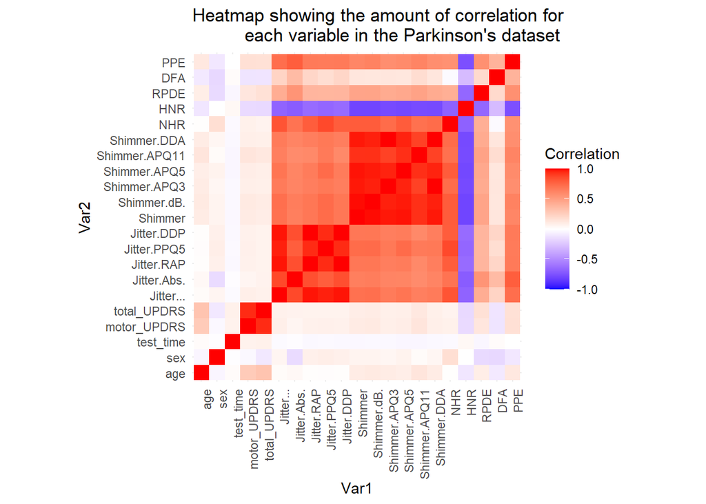

```r
parkinsons_data$sex <- as.numeric(parkinsons_data$sex) #cor function requires numeric data.
selected_variables <- parkinsons_data%>% select(-subject., -severity)


correlation_matrix <- cor(selected_variables)

ggplot(data = reshape2::melt(correlation_matrix), aes(Var1, Var2, fill = value)) +
  geom_tile() +
  scale_fill_gradient2(low = "blue", mid = "white", high = "red",
                       midpoint = 0, limit = c(-1,1), space = "Lab",
                       name="Correlation") +
  theme_minimal() +
  coord_fixed() +
  theme(axis.text.x = element_text(angle = 90, hjust = 1)) +
  ggtitle("Heatmap showing the amount of correlation for
          each variable in the Parkinson's dataset")
```

Looking at the heat map, there appears to be a strong correlation between the features for the shimmer and jitter variables.

### **Methods**

R Studio version 2023.12.1.402 ‘Ocean Storm’ was used for this investigation.

To address the issue of multicollinearity and a high number of variables, let us perform Principal Component Analysis (PCA) to reduce the dimensionality of the dataset. PCA is in an Unsupervised Learning and is also good at removing inter-feature correlation by capturing the variation within the dataset. As we are looking to confirm if quantified voice patterns can be used to determine severity of Parkinson’s disease, we want to create an accurate model that only uses variables that can be easily obtained. Therefore, the ‘severity’, ‘motor_UPDRS’ and ‘total_UPDRS’ variables will be removed. Next, the data will be required to be scaled. This is as the variation between the variables are different, therefore the mean of each variable will be scaled to equal zero and the standard deviation will equal 1.

Next we will add the ‘severity’ variable into the PCA output by using the cbind() function and index the appropriate number of principal components based on the scree plot and summary of the principal components obtained. Using this unsupervised learning technique should provide us with some insights as to which variables account for the majority of the variation within the dataset, as well as providing data appropriate for the next stage for our analysis. Next, we will prepare different supervised learning models and assess which will perform the best using an AUC-ROC plot analysis to determine which is this best performing model. For this we will be using logistic regression, random forest and k-nearest neighbours to maximise the chance of determining Parkinson’s disease severity using voice pattern analysis.

For each supervised learning algorithm, the null and alternate hypothesis is as follows:

```r
#<strong>HO: There is no significant relationship between the severity of Parkinson's disease and the variables derived from voice pattern analysis.

#HA: There is significant relationship between the severity of Parkinson's disease and the variables derived from voice pattern analysis.</strong>
```

The data will need to be converted into a training set and test set by dividing the data up into two portions. 80% of the data will be used for training and 20% will be used as the test. This provides around 4700 observations for training which is a good amount to provide an accurate model. Around 1200 observations will provide us with a good amount of feedback into how well the model is performing. If we had only a small amount of test data, we may find that no false negatives or false positives were detected, our test sample size will not have this issue.

For each of the supervised learning methods used, a 10 fold non overlapping cross validation procedure will be used. This way, multiple samples are taken from the data to create the models, improving the accuracy. We will set the seed of each model so that the same data is used, this will help when comparing the performance of each model. Next, we can view the confusion matrix formed from each model and view this information on the AUC-ROC curve. After obtaining results for the models created, we will continue to explore the data using another unsupervised learning method of cluster analysis. We will use k-means analysis to perform further analysis on the dataset. The k-means analysis will be performed using the same selected variables that was used previously in this investigation. From this analysis, we will be able to see the number of clusters which have formed by using the elbow and silhouette methods.

### **Results**

```r
selected_variables <- parkinsons_data %>% select(-subject., -motor_UPDRS, -total_UPDRS, -severity) # Remove variables that would not allow the data to form patterns naturally. Remove -subject variable as this is not a characteristic of the data.

pr.out <- prcomp(selected_variables, center = T, scale=T) ## data is scaled when performing PCA

pr.out$rotation
```

```
##                       PC1         PC2         PC3          PC4          PC5
## age           -0.02540776 -0.17437773  0.20358676  0.673000287 -0.543476165
## sex           -0.00970696 -0.19931416 -0.54133557 -0.022216570  0.084200066
## test_time      0.01022615  0.03315434  0.02585249  0.666640029  0.730835525
## Jitter...     -0.26645967  0.26221098 -0.19535543  0.071181606 -0.065197864
## Jitter.Abs.   -0.24926407  0.31611035  0.06433702  0.047313276 -0.054204243
## Jitter.RAP    -0.25860025  0.26999461 -0.23473962  0.064783105 -0.064495180
## Jitter.PPQ5   -0.26464377  0.19247935 -0.23939336  0.058101926 -0.046086487
## Jitter.DDP    -0.25860162  0.26999774 -0.23473012  0.064790191 -0.064484614
## Shimmer       -0.27851170 -0.24598783  0.04029245 -0.051449896  0.069141600
## Shimmer.dB.   -0.27882098 -0.23665551  0.04121141 -0.036906904  0.058086873
## Shimmer.APQ3  -0.26908354 -0.26746112  0.05859230 -0.061609969  0.088300935
## Shimmer.APQ5  -0.27448590 -0.25747088  0.03171713 -0.063663995  0.077702261
## Shimmer.APQ11 -0.26171547 -0.24074271  0.11990951 -0.048915607  0.055078147
## Shimmer.DDA   -0.26908312 -0.26746238  0.05859182 -0.061608342  0.088304180
## NHR           -0.25827182 -0.02388428 -0.24677644  0.034736603 -0.037110558
## HNR            0.25663374  0.02774582 -0.20579898  0.036459987 -0.002498693
## RPDE          -0.16723414  0.08350027  0.36808157  0.003054265 -0.140118952
## DFA           -0.06990015  0.36150708  0.37966705 -0.241244720  0.299847964
## PPE           -0.22991198  0.23325279  0.21580465  0.065586244 -0.045239262
##                       PC6         PC7         PC8           PC9         PC10
## age            0.30530926 -0.25070625  0.12702275 -0.0355024240  0.059426185
## sex            0.72283966  0.31107430 -0.01329711  0.1276846855 -0.047712934
## test_time     -0.08098752  0.10916589  0.02213940  0.0016955150 -0.005001979
## Jitter...     -0.04009777 -0.05411989  0.05818236 -0.0002358828 -0.119891103
## Jitter.Abs.   -0.07112680  0.01596586 -0.09191454  0.3165887018  0.233123187
## Jitter.RAP    -0.03515545 -0.08790786  0.12641996  0.1881706164 -0.075265445
## Jitter.PPQ5   -0.06010397 -0.07100324  0.10028222 -0.2851544927 -0.090850598
## Jitter.DDP    -0.03515977 -0.08792282  0.12640249  0.1881225322 -0.075243962
## Shimmer       -0.02718371 -0.07781184  0.02962480  0.0328943451 -0.047178071
## Shimmer.dB.   -0.02629324 -0.06664470 -0.02003689  0.0038026405 -0.086593698
## Shimmer.APQ3  -0.03385562 -0.11740184  0.04628784  0.3409648714  0.078277469
## Shimmer.APQ5  -0.02875846 -0.08130975  0.04115788 -0.1223657154 -0.052313476
## Shimmer.APQ11  0.03389921 -0.06742506 -0.03382948 -0.3370348891 -0.432763646
## Shimmer.DDA   -0.03385413 -0.11740794  0.04628429  0.3409669594  0.078284784
## NHR           -0.13409235  0.13394548  0.04882420 -0.5744244974  0.366433350
## HNR           -0.14722426 -0.24490457  0.19372997  0.0616544294 -0.644907136
## RPDE          -0.01449789  0.73171588  0.44386177  0.0583941774 -0.237468440
## DFA            0.53656484 -0.35732125  0.31058945 -0.1730886326  0.063095937
## PPE            0.17751646  0.12062647 -0.76651952 -0.0279515568 -0.288641928
```

[output cut: 25 more lines]

```
## Jitter.Abs.   -0.0711696956  0.0074697501  4.063057e-06  3.016637e-06
## Jitter.RAP    -0.2445474436  0.0024525298  7.070711e-01  2.317345e-03
## Jitter.PPQ5   -0.2962223040  0.0567093923  8.839928e-05  1.110244e-05
## Jitter.DDP    -0.2446172123  0.0023999621 -7.071349e-01 -2.304178e-03
## Shimmer       -0.1013711924 -0.8660590678  5.174975e-05  3.325650e-05
## Shimmer.dB.   -0.0946844373  0.4437204586  2.689045e-05 -1.579859e-05
## Shimmer.APQ3   0.0659422606  0.1264184365  2.321910e-03 -7.071033e-01
## Shimmer.APQ5   0.0643734884  0.0990980644 -1.608893e-04 -2.909407e-05
## Shimmer.APQ11 -0.0055602504  0.0596802579  4.188358e-05  1.002281e-05
## Shimmer.DDA    0.0659929122  0.1264685693 -2.299624e-03  7.071027e-01
## NHR            0.0069177151  0.0255674864  1.336959e-05  6.429114e-06
## HNR           -0.0229262423  0.0081268330 -2.320705e-05  6.577182e-06
## RPDE          -0.0141669701  0.0096908495 -1.921657e-05  6.157840e-06
## DFA            0.0018125319  0.0080965310  8.174501e-06 -5.123479e-07
## PPE           -0.0478891124 -0.0118776775 -5.513454e-06  2.735108e-06
```

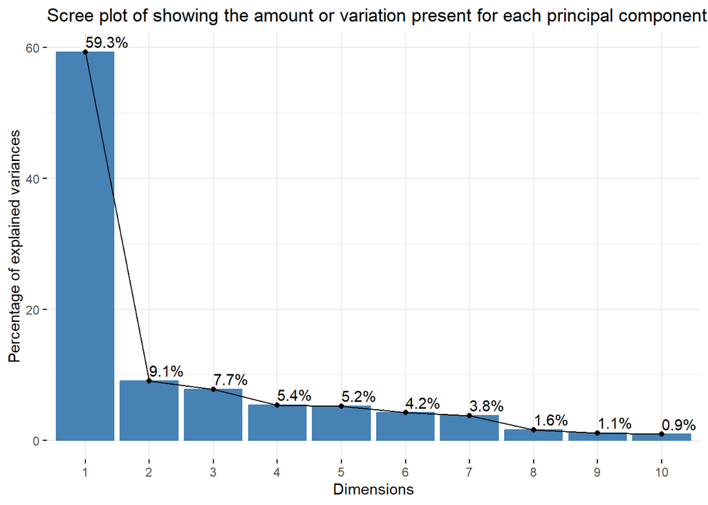

```r
pca_data <- as.data.frame(pr.out$x)

comb_data <- cbind(severity = parkinsons_data$severity, pca_data) # adds the severity column back into the PCA data.
comb_data$severity <- as.factor(comb_data$severity) # turns severity class into factor type. Necessary for algorithms.

fviz_eig(pr.out, addlabels = T) +
  ggtitle("Scree plot of showing the amount or variation present for each principal component")
```

Observing the scree plot from the PCA, there does seem to be a significant amount of variation captured within the first two principal components

```r
selected_PC <- comb_data[1:7] # Select the number of principal components that accounts for over 90% of the variation.
summary(pr.out)
```

```
## Importance of components:
##                           PC1     PC2     PC3     PC4     PC5    PC6     PC7
## Standard deviation     3.3570 1.31356 1.21311 1.00945 0.99530 0.8922 0.84610
## Proportion of Variance 0.5931 0.09081 0.07745 0.05363 0.05214 0.0419 0.03768
## Cumulative Proportion  0.5931 0.68396 0.76141 0.81504 0.86718 0.9091 0.94676
##                            PC8     PC9    PC10    PC11    PC12    PC13    PC14
## Standard deviation     0.54482 0.45466 0.41078 0.39018 0.31450 0.20227 0.14222
## Proportion of Variance 0.01562 0.01088 0.00888 0.00801 0.00521 0.00215 0.00106
## Cumulative Proportion  0.96238 0.97326 0.98214 0.99016 0.99536 0.99751 0.99858
##                           PC15    PC16    PC17      PC18      PC19
## Standard deviation     0.11785 0.09306 0.06675 0.0006146 0.0001444
## Proportion of Variance 0.00073 0.00046 0.00023 0.0000000 0.0000000
## Cumulative Proportion  0.99931 0.99977 1.00000 1.0000000 1.0000000
```

Originally, only the first two principal components were used due to there being a very distinctive elbow at 2 principal components. However, it could be seen that the performance of each model was quite poor. This could be due to the fact that only 68% of the total variation within the dataset has been captured. This could make the models formed inaccurate, missing key patterns integral to from a good prediction. From using a variety of principal components and fine tuning, it could be seen that the best performance were captured using 6 principal components. With this number of principal components, around 90% of the total data is attributed for this dataset. This could explain why the models perform well using this number of principal components while addressing the original issue of high multicollinearity within the dataset.

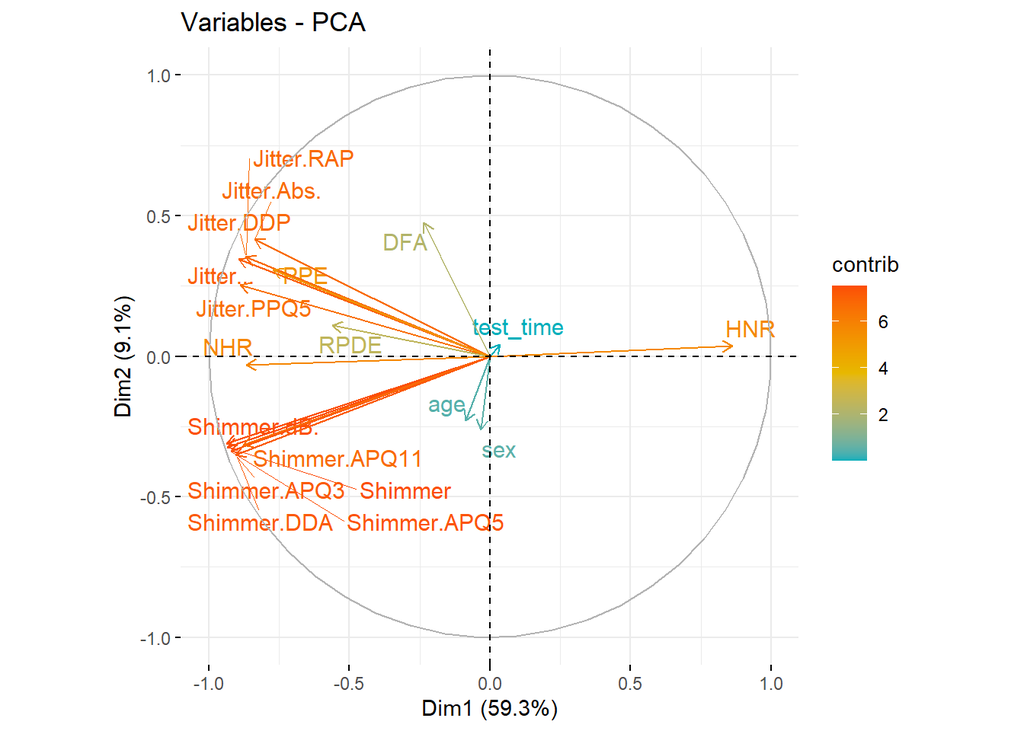

```r
fviz_pca_var(pr.out,
             col.var = "contrib",
             gradient.cols = c("#00AFBB", "#E7B800", "#FC4E07"),
             repel = T)
```

From the plot showing the eigenvectors for each variable, it can be seen that the jitter and shimmer variables all account for a similar amount of the variation. This could potentially suggest that these variables could be used to predict the degree as to how much a patient is affected by Parkinson’s disease.

### Logistic Regression

```r
set.seed(10)
model_lr <- train(form = severity ~ .,
                 data = training_data,
                 trControl = trainControl(method = 'cv', number = 10),
                 method = 'glm',
                 family = 'binomial')

summary(model_lr)
```

```
##
## Call:
## NULL
##
## Deviance Residuals:
##     Min       1Q   Median       3Q      Max
## -1.6621  -1.1878   0.7683   1.0889   1.8890
##
## Coefficients:
##              Estimate Std. Error z value Pr(>|z|)
## (Intercept)  0.196678   0.030137   6.526 6.75e-11 ***
## PC1          0.066348   0.009014   7.361 1.83e-13 ***
## PC2          0.122260   0.022854   5.350 8.81e-08 ***
## PC3         -0.162648   0.025212  -6.451 1.11e-10 ***
## PC4         -0.161657   0.030302  -5.335 9.56e-08 ***
## PC5          0.255432   0.030504   8.374  < 2e-16 ***
## PC6          0.173660   0.033634   5.163 2.43e-07 ***
## ---
## Signif. codes:  0 '***' 0.001 '**' 0.01 '*' 0.05 '.' 0.1 ' ' 1
##
## (Dispersion parameter for binomial family taken to be 1)
##
##     Null deviance: 6475.5  on 4699  degrees of freedom
## Residual deviance: 6227.9  on 4693  degrees of freedom
## AIC: 6241.9
##
## Number of Fisher Scoring iterations: 4
```

```r
model_lr
```

```
## Generalized Linear Model
##
## 4700 samples
##    6 predictor
##    2 classes: 'advanced', 'mild'
##
## No pre-processing
## Resampling: Cross-Validated (10 fold)
## Summary of sample sizes: 4230, 4229, 4229, 4230, 4230, 4230, ...
## Resampling results:
##
##   Accuracy   Kappa
##   0.5942568  0.1635475
```

```r
set.seed(10)
prediction_lr <- predict(model_lr, newdata = test_data)
confusionMatrix(prediction_lr, test_data$severity)
```

```
## Confusion Matrix and Statistics
##
##           Reference
## Prediction advanced mild
##   advanced      230  161
##   mild          302  482
##
##                Accuracy : 0.606
##                  95% CI : (0.5774, 0.634)
##     No Information Rate : 0.5472
##     P-Value [Acc > NIR] : 2.751e-05
##
##                   Kappa : 0.1862
##
##  Mcnemar's Test P-Value : 7.700e-11
##
##             Sensitivity : 0.4323
##             Specificity : 0.7496
##          Pos Pred Value : 0.5882
##          Neg Pred Value : 0.6148
##              Prevalence : 0.4528
##          Detection Rate : 0.1957
##    Detection Prevalence : 0.3328
##       Balanced Accuracy : 0.5910
##
##        'Positive' Class : advanced
##
```

### kNN

```r
set.seed(10)
model_knn <- train(form = severity ~ .,
                 data = training_data,
                 trControl = trainControl(method = 'cv', number = 10),
                 method = 'knn')

summary(model_knn)
```

```
##             Length Class      Mode
## learn       2      -none-     list
## k           1      -none-     numeric
## theDots     0      -none-     list
## xNames      6      -none-     character
## problemType 1      -none-     character
## tuneValue   1      data.frame list
## obsLevels   2      -none-     character
## param       0      -none-     list
```

```r
model_knn
```

```
## k-Nearest Neighbors
##
## 4700 samples
##    6 predictor
##    2 classes: 'advanced', 'mild'
##
## No pre-processing
## Resampling: Cross-Validated (10 fold)
## Summary of sample sizes: 4230, 4229, 4229, 4230, 4230, 4230, ...
## Resampling results across tuning parameters:
##
##   k  Accuracy   Kappa
##   5  0.8206466  0.6390064
##   7  0.8176606  0.6330353
##   9  0.8099969  0.6172613
##
## Accuracy was used to select the optimal model using the largest value.
## The final value used for the model was k = 5.
```

```r
set.seed(10)
prediction_knn <- predict(model_knn, newdata = test_data)
confusionMatrix(prediction_knn, test_data$severity)
```

```
## Confusion Matrix and Statistics
##
##           Reference
## Prediction advanced mild
##   advanced      434   98
##   mild           98  545
##
##                Accuracy : 0.8332
##                  95% CI : (0.8106, 0.8541)
##     No Information Rate : 0.5472
##     P-Value [Acc > NIR] : <2e-16
##
##                   Kappa : 0.6634
##
##  Mcnemar's Test P-Value : 1
##
##             Sensitivity : 0.8158
##             Specificity : 0.8476
##          Pos Pred Value : 0.8158
##          Neg Pred Value : 0.8476
##              Prevalence : 0.4528
##          Detection Rate : 0.3694
##    Detection Prevalence : 0.4528
##       Balanced Accuracy : 0.8317
##
##        'Positive' Class : advanced
##
```

### Random Forest

```r
set.seed(10)
model_rf <- train(form = severity ~ .,
                  data = training_data,
                  trControl = trainControl(method = 'cv', number = 10),
                  method = 'rf')

summary(model_rf)
```

```
##                 Length Class      Mode
## call               4   -none-     call
## type               1   -none-     character
## predicted       4700   factor     numeric
## err.rate        1500   -none-     numeric
## confusion          6   -none-     numeric
## votes           9400   matrix     numeric
## oob.times       4700   -none-     numeric
## classes            2   -none-     character
## importance         6   -none-     numeric
## importanceSD       0   -none-     NULL
## localImportance    0   -none-     NULL
## proximity          0   -none-     NULL
## ntree              1   -none-     numeric
## mtry               1   -none-     numeric
## forest            14   -none-     list
## y               4700   factor     numeric
## test               0   -none-     NULL
## inbag              0   -none-     NULL
## xNames             6   -none-     character
## problemType        1   -none-     character
## tuneValue          1   data.frame list
## obsLevels          2   -none-     character
## param              0   -none-     list
```

```r
model_rf
```

```
## Random Forest
##
## 4700 samples
##    6 predictor
##    2 classes: 'advanced', 'mild'
##
## No pre-processing
## Resampling: Cross-Validated (10 fold)
## Summary of sample sizes: 4230, 4229, 4229, 4230, 4230, 4230, ...
## Resampling results across tuning parameters:
##
##   mtry  Accuracy   Kappa
##   2     0.8393687  0.6755562
##   4     0.8414941  0.6797354
##   6     0.8423420  0.6814667
##
## Accuracy was used to select the optimal model using the largest value.
## The final value used for the model was mtry = 6.
```

```r
set.seed(10)
prediction_rf <- predict(model_rf, newdata = test_data)
confusionMatrix(prediction_rf, test_data$severity)
```

```
## Confusion Matrix and Statistics
##
##           Reference
## Prediction advanced mild
##   advanced      445   80
##   mild           87  563
##
##                Accuracy : 0.8579
##                  95% CI : (0.8366, 0.8773)
##     No Information Rate : 0.5472
##     P-Value [Acc > NIR] : <2e-16
##
##                   Kappa : 0.7129
##
##  Mcnemar's Test P-Value : 0.6424
##
##             Sensitivity : 0.8365
##             Specificity : 0.8756
##          Pos Pred Value : 0.8476
##          Neg Pred Value : 0.8662
##              Prevalence : 0.4528
##          Detection Rate : 0.3787
##    Detection Prevalence : 0.4468
##       Balanced Accuracy : 0.8560
##
##        'Positive' Class : advanced
##
```

### AUC-ROC graph

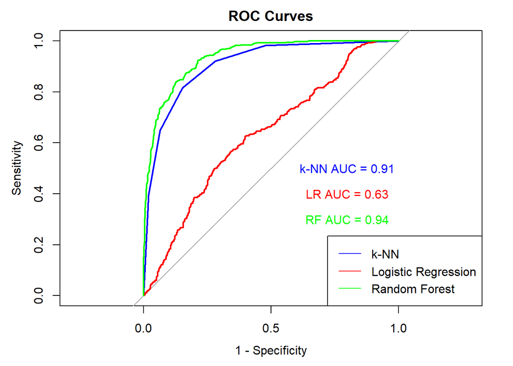

```r
set.seed(10)
test_data$severity_numeric <- ifelse(test_data$severity == "advanced", 1, 0) # Insert a variable that is
                                                                            # in numeric format for severity

prob_knn <- predict(model_knn, newdata = test_data, type = "prob") # Create probability values for the ROC curve
                                                                  # for each supervised learning model.
prob_rf <- predict(model_rf, newdata = test_data, type = "prob")

prob_lr <- predict(model_lr, newdata = test_data, type = "prob")


roc_knn <- roc(test_data$severity_numeric, prob_knn[,"advanced"]) # Creates the roc curve for each model

roc_lr <- roc(test_data$severity_numeric, prob_lr[,"advanced"])

roc_rf <- roc(test_data$severity_numeric, prob_rf[,"advanced"])


plot(roc_knn, col = "blue", main = "ROC Curves", legacy.axes = TRUE, print.auc = F) # plot the curves on one graph
plot(roc_lr, col = "red", add = TRUE, print.auc = F, legacy.axes = TRUE)
plot(roc_rf, col = "green", add = TRUE, print.auc = F, legacy.axes = TRUE)


legend("bottomright", legend = c("k-NN", "Logistic Regression", "Random Forest"), col = c("blue", "red", "green"), lty = c(1, 1, 1)) # Add a legend to the graph

text(0.2, 0.5, paste("k-NN AUC =", round(auc(roc_knn), 2)), col = "blue") # print the AUC scores on the graph
text(0.2, 0.4, paste("LR AUC =", round(auc(roc_lr), 2)), col = "red")
text(0.2, 0.3, paste("RF AUC =", round(auc(roc_rf), 2)), col = "green")
```

```r
#Ho: The variables associated with voice pattern analysis will not form into two cluster types for Parkinson's disease severity categorical type.

#HA: The variables associated with voice pattern analysis will form into two cluster types for Parkinson's disease severity categorical type.
```

```r
selected_variables <- parkinsons_data %>% select(-subject., -motor_UPDRS, -total_UPDRS, -severity)

std_cluster <- scale(selected_variables) ## scale the dataset
set.seed(10)
k2 <- kmeans(std_cluster, centers = 2, nstart = 10)

k2$betweenss/k2$totss ## calculated to show variation explained by clustering
```

```
## [1] 0.3353972
```

```r
parkinsons_data$severity <- as.character(parkinsons_data$severity)

table(k2$cluster) %>% prop.table()
```

```
##
##          1          2
## 0.03642553 0.96357447
```

```r
table(parkinsons_data$severity) %>% prop.table()
```

```
##
## advanced     mild
## 0.453617 0.546383
```

When observing the amount of variation which is explained by the clusters within the dataset, the score is only 34% which indicates that the clusters are not very distinct. When viewing the ratio of the two severity classes, the ratio is 45:55. When viewing the cluster sizes, it could be observed that the one cluster makes up 96% of the data and the other only makes up 4%. It would appear that most of the data is clustered in one area. Let us identify if there are truly 2 clusters whch form within the dataset using the elbow method and silhouette techniques.

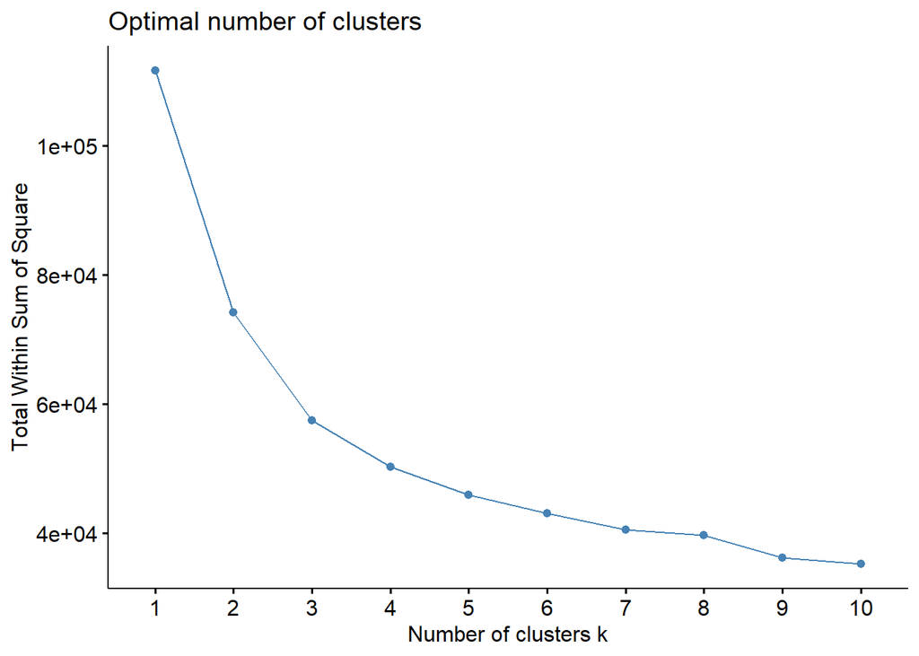

```r
set.seed(10)
fviz_nbclust(std_cluster, kmeans, method='wss')
```

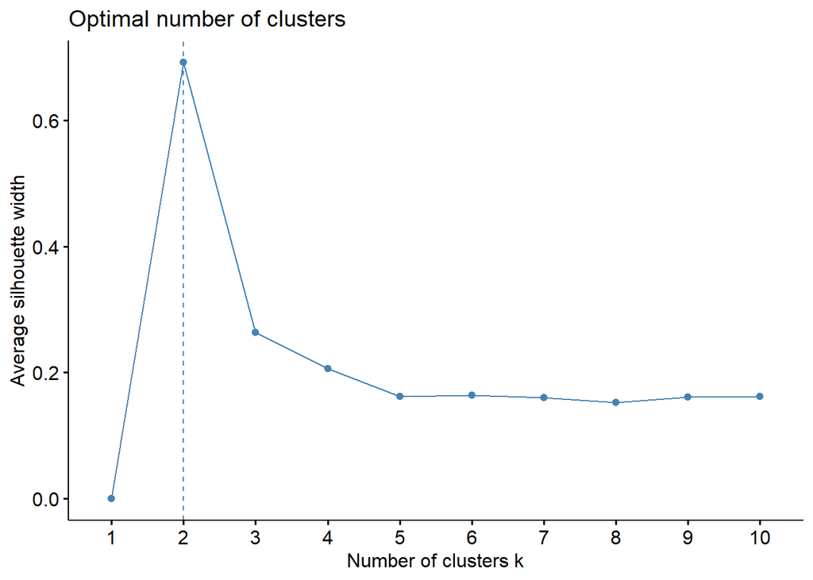

```r
set.seed(10)
fviz_nbclust(std_cluster, kmeans, method='silhouette')
```

There was not a very distinctive elbow formed using the elbow method, but there did seem to be an a slight elbow that formed between 2 and 3 clusters.When viewing the silhouette method, it was very clear that the number of clusters in the dataset is 2. Let us see the clusters visually using k = 2 to see if there is a pattern of the position of ‘advanced’ and ‘mild’ within the 2 clusters which have been identified.

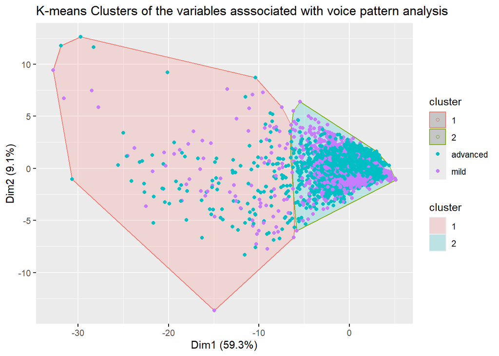

```r
fviz_cluster(list(data = std_cluster, cluster = k2$cluster),
             geom = "point",
             shape = 1,
             show.clust.cent = F) +
  geom_point(aes(colour = parkinsons_data$severity)) +
  ggtitle("K-means Clusters of the variables asssociated with voice pattern analysis")
```

### Conclusion

Also, the patients used for this analysis were early onset parkinson cases. Therefore, the voice readings and total UPDRS scores would have only been from a small proportion of the total scale. This could potentially explain why there was no distinct clusters formed in the dataset when performing cluster analysis. It may also explain why the supervised learning algorithms did not perform as well as they should have. It would be interesting if it were possible to collect further data from patients who had more developed cases of Parkinson’s disease and from a larger number of patients as well. All that we have been able to prove in this report, is that we can loosely diagnose the same 42 patients with slightly different voice patterns.

This method could be a useful tool to aid doctors in the diagnosis of parkinson’s disease, but further study will be required to develop more robust algorithms using a greater number of patients.

### References:

Ivey, F.M, Katzel, L,I. Sorkin, J.D, Macko, R. F, Shulman, L. M. (2012). The Unified Parkinson’s Disease Rating Scale as a predictor of peak aerobic capacity and ambulatory function. Journal of Rehabilitation Research and Development, 49(8), 1269-1276. https://doi.org/10.1682/jrrd.2011.06.0103

James,G. Witten,D. Hastie, T. Tibshirani, R.(2021), ‘An introduction to Statistical Learning’. Springer.

Little, M.A, McSharry, P.E, Hunter, E.J, Spielman, J, Ramig, L.O. (2009). Suitability of dysphonia measurements for telemonitoring of Parkinson’s disease. IEEE Transactions on Biomedical Engineering, 56(4), 1015. https://doi.org/10.1109/TBME.2008.2005954

Neurotoolkit. (2018). Unified Parkinson’s Disease Rating Scale – NeurologyToolKit. https://neurotoolkit.com/updrs/

Tsanas, A. Little, M,A. McSharry, P.E. Ramig, L.O. (2010), ‘Accurate telemonitoring of Parkinson’s disease progression by non-invasive speech tests’, IEEE Transactions on Biomedical Engineering, 57(4), 884-893. https://DOI:10.1109/TBME.2009.2036000

UCI Machine Learning Repository.(2023). Parkinsons Telemonitoring. https://archive.ics.uci.edu/dataset/189/parkinsons+telemonitoring

Verzani, J. (2014). ‘Using R for Introductory statistics’. CRC Press.